# Netify Workshop

Cassy Dorff and Shahryar Minhas

2024-05-21

## Package Overview

This vignette provides a high level overview of our package from start to finish. The best use of this vignette is to introduce the main components of the package to larger audiences. This overview covers our primary functions with data examples and minimal writing.

`netify` goals:

1. Create: Netify your data! We Make it easy for users to create networks from raw data in $R$ as well as add additional features, such as nodal and dyadic variables, to the network object.
2. Explore: Explore characteristics of the network you created, like summary statistics at both the network and actor levels. Visualize your network.
3. Advance: Advance your network analysis to the next stage by preparing it for use in other network packages and modeling approaches.

`netify` provides a suite of primary functions to help achieve these goals:

| Create💡 | Explore 🔎 | Advance ️🚀 |
| --- | --- | --- |
| `netify()` | `peek()` | `prep_for_amen()` |
| `add_nodal()` | `summary_actor()` | `prep_for_igraph()` |
| `add_dyad()` | `summary()` | `prep_for_statnet()` |
| `subset_netlet()` | `plot_actor_stats()` |  |
|  | `plot_graph_stats()` |  |
|  | `plot()` |  |

`netify` can take dyadic data or edgelists to get started.

- The package can also create different types of networks including:
  - cross sectional networks
  - longitudinal (with static and varying actor composition)
  - bipartite networks
  - multilayer
- As well as create networks with different edge types:
  - weighted
  - binary
  - symmetric or non-symmetric

## Step 1: Create 💡

Begin by loading packages and supplying the data. We will use the `peacesciencer` package to grab some familiar data.

```r
# load packages
library(netify)

# install extra packages for this vignette
if(!'tidyverse' %in% rownames(installed.packages())){
  install.packages('tidyverse', repos='https://cloud.r-project.org') }
if(!'peacesciencer' %in% rownames(installed.packages())){
  install.packages('peacesciencer', repos='https://cloud.r-project.org') }
# load necessary packages for this vignette
library(peacesciencer)
library(tidyverse)

# organize external data for peacesciencer
peacesciencer::download_extdata()

# create dyadic data set over time using peacesciencer
cow_dyads <- create_dyadyears(
     subset_years = c(1995:2014)
     ) |>
    # add mids
    add_cow_mids() |>
    # add capital distance
    add_capital_distance() |>
    # add democracy
    add_democracy() |>
    # add gdp
    add_sdp_gdp()
```

Next, create a `netlet` object from the above COW data frame using our package’s core function `netify.` There are a number of useful parameters, but the most important ones to highlight are:

- `dyad_data` is a dyadic data.frame that should have at least the following variables used to specify actors:
  - `actor1`: character indicating actor 1 variable in the data
  - `actor2`: character indicating actor 2 variable in the data
- `netify_type` is a type of netlet object (`cross-sec`, `longit_list`, or `longit_array`).

```r
mid_long_network <- netify(
  cow_dyads,
  actor1='ccode1', actor2='ccode2', time='year',
  weight='cowmidonset',
  actor_time_uniform=FALSE,
  sum_dyads=FALSE, symmetric=TRUE,
  diag_to_NA=TRUE, missing_to_zero=TRUE,
  nodal_vars = c('v2x_polyarchy1', 'v2x_polyarchy2'),
  dyad_vars = c('capdist'),
  dyad_vars_symmetric = c(TRUE)
  )
```

```
## ! Warning: Converting `actor1` and/or `actor2` to character vector(s).
```

**Congratulations** you have created a network object! 🎉

We can also add nodal and dyadic data after we’ve created the network via the `add_nodal()` and `add_dyad()` functions.

Let’s assume that we had information about each actor in the network that we’d like to add as a nodal variable after we already made the network object. This could be from our original data set or elsewhere. For example, lets add a logged variable measuring gdp for each node in the network over time:

```r
# create a vector of nodal data
node_data <- unique(cow_dyads[,c("ccode1", "year", "wbgdppc2011est2")])
node_data$wbgdppc2011est2_log <- log(node_data$wbgdppc2011est2)

# add nodal variable to netlet object
mid_long_network <- add_nodal(
    netlet = mid_long_network,
    node_data = node_data,
    actor = "ccode1",
    time = "year"
)

# create another dyadic var in cow
cow_dyads$log_capdist = log(cow_dyads$capdist + 1)

# now lets add this to the netlet
mid_long_network <- add_dyad(
  netlet = mid_long_network,
  dyad_data= cow_dyads,
  actor1= 'ccode1',
  actor2='ccode2',
  time='year',
  dyad_vars = 'log_capdist',
  dyad_vars_symmetric = TRUE
)
```

## Step 2: Explore 🔎

We made a network, so let’s look at it. First, we might want to take a `peek` at the network object to see if the matrix looks the way we’d expect it to look. This function lets you glance at a specific slice of the network if it is longitudinal or the entire network if it is cross-sectional.

```r
peek(mid_long_network, when_to_peek = c('2012'), what_to_peek = c(13, 15:24))
```

```
## $`2012`
##      2 200 205 210 211 212 220 221 223 225 230
## 2   NA   0   0   0   0   0   0   0   0   0   0
## 200  0  NA   0   0   0   0   0   0   0   0   1
## 205  0   0  NA   0   0   0   0   0   0   0   0
## 210  0   0   0  NA   0   0   0   0   0   0   0
## 211  0   0   0   0  NA   0   0   0   0   0   0
## 212  0   0   0   0   0  NA   0   0   0   0   0
## 220  0   0   0   0   0   0  NA   0   0   0   0
## 221  0   0   0   0   0   0   0  NA   0   0   0
## 223  0   0   0   0   0   0   0   0  NA   0   0
## 225  0   0   0   0   0   0   0   0   0  NA   0
## 230  0   1   0   0   0   0   0   0   0   0  NA
```

Next, let’s examine a few basic summary statistics about the network using our`summary()` function.

```r
# create data.frame that provides network-level summary stats
# for each year of the network
mid_long_summary <- summary(mid_long_network)
```

We can also make a quick visualization of network statistics over time using the summary statistics data frame.

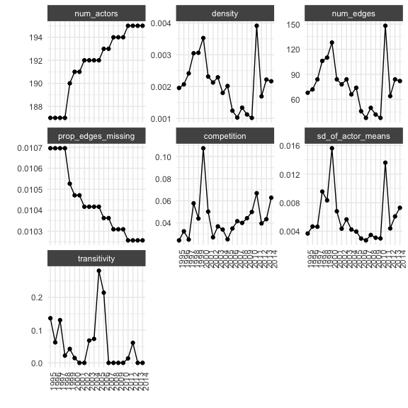

```r
plot_graph_stats(mid_long_summary)
```

```r
# every year & every actor (messy!) but check out help file
summary_actor_mids <- summary_actor(mid_long_network)
head(summary_actor_mids)
```

```
##   actor time degree   prop_ties network_share closeness betweenness
## 1   100 1995      1 0.005376344    0.01470588         1           0
## 2   101 1995      1 0.005376344    0.01470588         1           0
## 3   110 1995      0 0.000000000    0.00000000       NaN           0
## 4   115 1995      0 0.000000000    0.00000000       NaN           0
## 5   130 1995      1 0.005376344    0.01470588         1           0
## 6   135 1995      1 0.005376344    0.01470588         1           0
##   eigen_vector
## 1 1.672256e-16
## 2 1.368329e-16
## 3 2.524488e-17
## 4 2.524488e-17
## 5 1.667726e-16
## 6 1.493188e-16
```

We can take a single actor and examine their statistic over time:

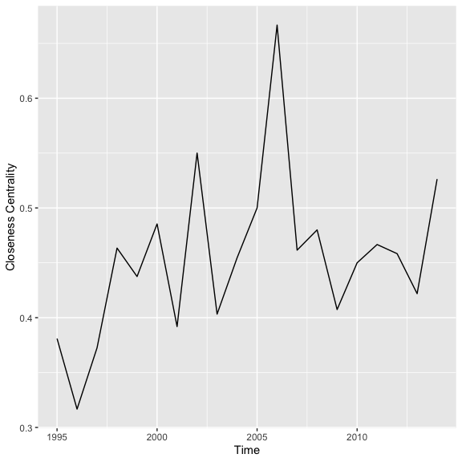

```r
actor_2 <- summary_actor_mids[summary_actor_mids$actor == 2, ]

ggplot(actor_2, aes(x = time, y = closeness)) +
  geom_line() +
  labs(x = "Time", y = "Closeness Centrality")
```

Or we can look at the distribution of the statistic for all actors over time:

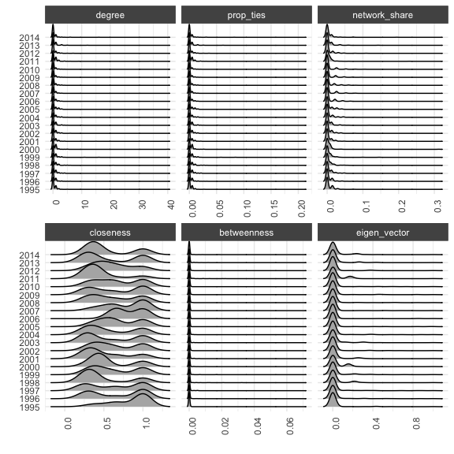

```r
# density plot across all actors
# and for each stat
plot_actor_stats(
  summary_actor_mids
  )
```

And then select a specific statistic to focus on:

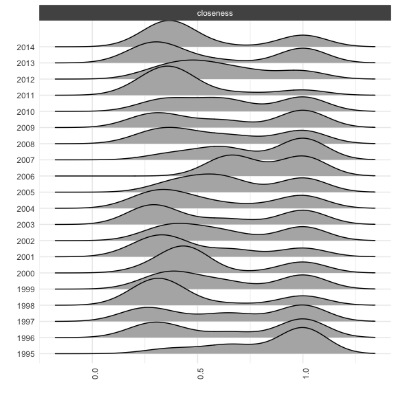

```r
# focus on closeness
plot_actor_stats(
  summary_actor_mids,
  specific_stats='closeness'
  )
```

Say that we wanted to showcase actor-specific statistics over time. We can use the plot_actor_stats function for this as well, though it’s **highly recommended** to subset to a few actors for a more legible plot.

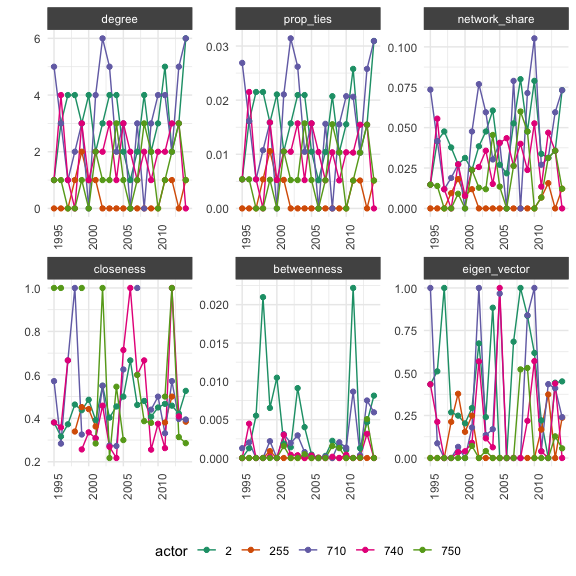

```r
# top 5 GDP countries (USA, China, Japan, Germany, India)
top_5 <- c("2", "710", "740", "255", "750")

#
plot_actor_stats(
  summary_actor_mids,
  across_actor = FALSE,
  specific_actors = top_5
)
```

Additionally, since the result of `plot_actor_stats` is a `ggplot2` object, users can also choose to facet the plot by actors and variables, as shown below:

[figure not shown]

```r
plot_actor_stats(
  summary_actor_mids,
  across_actor = FALSE,
  specific_actors = top_5
  ) +
  facet_grid(variable~actor, scales='free')
```

Instead of looking at summary statistics, we also might want to simply visualize the entire network. We can do this by plotting the netify object. (Isolates removed by default and seed set to 6886 for node layout).

Our goal was to make this super easy for plotting time-varying attributes or actors.

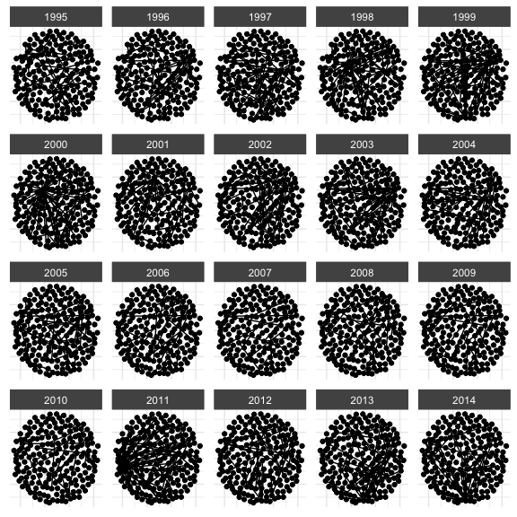

```r
# default plot
plot.netify(mid_long_network,
            static_actor_positions = TRUE,
            remove_isolates = FALSE)
```

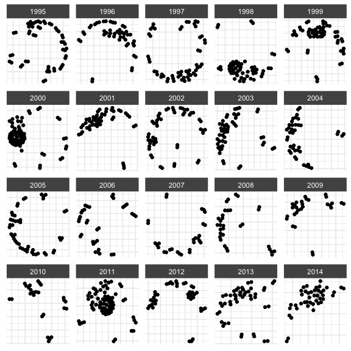

```r
# a little cleaner
plot(
    mid_long_network,
    edge_color='grey',
    node_size=2
)
```

We can also use `netify` functions to explore actor level summary statistics in the network graph.

```r
# add actor variables from summary_actor_mids
mid_long_network = add_nodal(
    mid_long_network,
    summary_actor_mids,
    actor='actor', time='time',
    node_vars = c('degree', 'prop_ties', 'eigen_vector'),
)

# print netlet to make sure they got added to nodal features
print(mid_long_network)
```

```
## ✔ Hello, you have created network data, yay!
```

```
## • Longitudinal
```

```
## • Unipartite
```

```
## • Symmetric
```

```
## • Weights from `cowmidonset`
```

```
## • No Loops Allowed
```

```
## • Longitudinal: 20 Periods
```

```
## • # Unique Row Actors: 195
```

```
## • # Unique Column Actors: 195
```

```
## • # Unique Actors: 195
```

```
##               nLoops nEdges     density recip propNA
## 1 cowmidonset    N/A   1546 0.002111837   N/A    N/A
```

```
## • Nodal Features: v2x_polyarchy1, v2x_polyarchy2, wbgdppc2011est2,
## wbgdppc2011est2_log, degree, prop_ties, eigen_vector
```

```
## • Dyad Features: capdist, log_capdist
```

```
## • Graph Features: None
```

```r
# if you're curious as to where they live
head(
  attr(
    mid_long_network,
    'nodal_data'
  )
)
```

```
##   actor time v2x_polyarchy1 v2x_polyarchy2 wbgdppc2011est2 wbgdppc2011est2_log
## 1   100 1995          0.595          0.883          10.740            2.373975
## 2   100 1996          0.574          0.881          10.768            2.376579
## 3   100 1997          0.581          0.868          10.798            2.379361
## 4   100 1998          0.558          0.867          10.833            2.382597
## 5   100 1999          0.553          0.864          10.860            2.385086
## 6   100 2000          0.562          0.863          10.888            2.387661
##   degree   prop_ties eigen_vector
## 1      1 0.005376344 1.672256e-16
## 2      0 0.000000000 0.000000e+00
## 3      1 0.005376344 0.000000e+00
## 4      0 0.000000000 6.966410e-17
## 5      0 0.000000000 0.000000e+00
## 6      1 0.005263158 4.953675e-03
```

```r
#i.e.,
head(attributes(mid_long_network)$nodal_data)
```

```
##   actor time v2x_polyarchy1 v2x_polyarchy2 wbgdppc2011est2 wbgdppc2011est2_log
## 1   100 1995          0.595          0.883          10.740            2.373975
## 2   100 1996          0.574          0.881          10.768            2.376579
## 3   100 1997          0.581          0.868          10.798            2.379361
## 4   100 1998          0.558          0.867          10.833            2.382597
## 5   100 1999          0.553          0.864          10.860            2.385086
## 6   100 2000          0.562          0.863          10.888            2.387661
##   degree   prop_ties eigen_vector
## 1      1 0.005376344 1.672256e-16
## 2      0 0.000000000 0.000000e+00
## 3      1 0.005376344 0.000000e+00
## 4      0 0.000000000 6.966410e-17
## 5      0 0.000000000 0.000000e+00
## 6      1 0.005263158 4.953675e-03
```

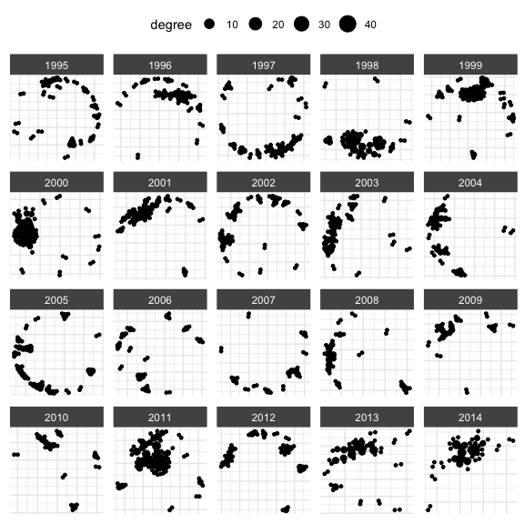

```r
# vary node size by degree
plot(
    mid_long_network,
    edge_color='grey',
    point_size_var='degree'
)
```

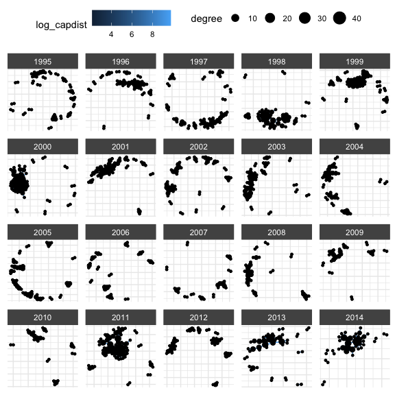

```r
# vary node size by degree
plot(
    mid_long_network,
    edge_color='grey',
    edge_color_var='log_capdist',
    point_size_var='degree'
)
```

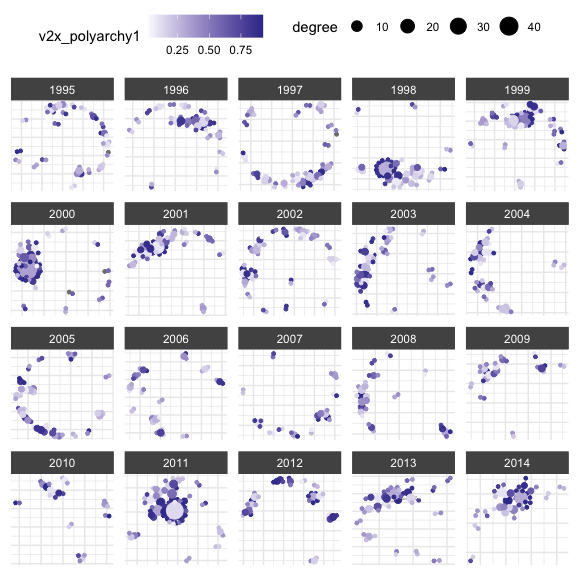

```r
# vary node color by polyarchy
plot(
    mid_long_network,
    edge_color='grey',
    point_size_var='degree',
    point_color_var='v2x_polyarchy1'
    ) +
    scale_color_gradient2()
```

We might also prefer to add labels, but only a select few:

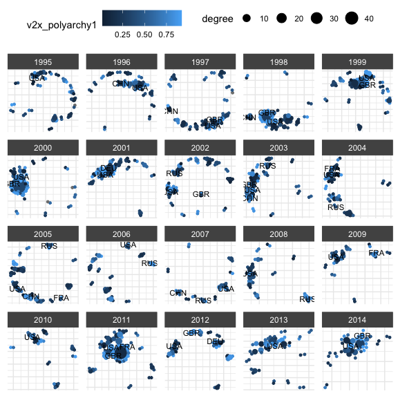

```r
library(countrycode)
cowns = countrycode(
    c('United States', 'China', 'Russia', 'France', 'Germany', 'United Kingdom'),
    'country.name', 'cown')
cabbs = countrycode(cowns, 'cown', 'iso3c')

plot(
    mid_long_network,
    edge_color='grey',
    point_size_var='degree',
    point_color_var='v2x_polyarchy1',
    select_text = cowns,
    select_text_display = cabbs,
    text_size = 3
    ) +
    scale_color_gradient2()
```

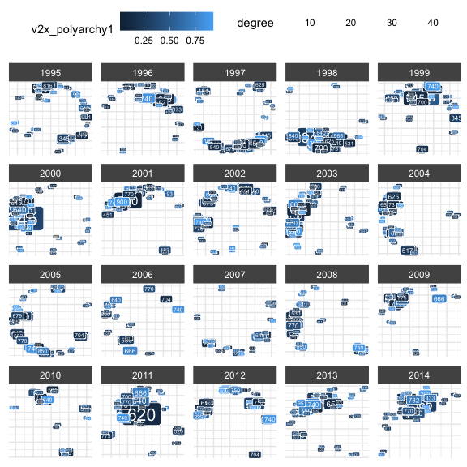

```r
# or we can go with labels only
# and remove points
plot(
    mid_long_network,
    edge_color='grey',
    add_points = FALSE,
    add_label = TRUE,
    label_size_var='degree',
    label_color = 'white',
    label_fill_var='v2x_polyarchy1'
    ) +
    scale_color_gradient2()
```

## Step 3: Advance 🚀

Once we have created and explored our network object, we might want to continue analyzing the data using different modeling approaches. `netify` makes this simple even though those models aren’t! And for the sake of convergence/degeneracy hell lets go with cross-sectional networks.

```r
# prep data
cow_cross = cow_dyads |>
  group_by(ccode1, ccode2) |>
  summarize(
    cowmidonset = ifelse(any(cowmidonset>0), 1, 0),
    capdist = mean(capdist),
    polity21 = mean(polity21, na.rm=TRUE),
    polity22 = mean(polity22, na.rm=TRUE),
    wbgdp2011est1 = mean(wbgdp2011est1, na.rm=TRUE),
    wbgdp2011est2 = mean(wbgdp2011est2, na.rm=TRUE),
    wbpopest1 = mean(wbpopest1, na.rm=TRUE),
    wbpopest2 = mean(wbpopest2, na.rm=TRUE)
  ) |>
  ungroup() |>
  mutate(
    capdist = log(capdist+1)
  )

# subset set to actors with 10mil pop
actor_to_keep = cow_cross |>
  select(ccode1, wbpopest1) |>
  filter(wbpopest1>log(10000000)) |>
  distinct(ccode1)

# filter cow_cross by actor_to_keep
cow_cross = cow_cross |>
  filter(ccode1 %in% actor_to_keep$ccode1) |>
  filter(ccode2 %in% actor_to_keep$ccode1)

# create netlet
mid_cross_network <- netify(
  cow_cross,
  actor1='ccode1', actor2='ccode2',
  weight='cowmidonset',
  sum_dyads=FALSE, symmetric=TRUE,
  diag_to_NA=TRUE, missing_to_zero=FALSE,
  nodal_vars = c(
    'polity21', 'polity22', 'wbgdp2011est1',
    'wbgdp2011est2', 'wbpopest1', 'wbpopest2'),
  dyad_vars = c('capdist'),
  dyad_vars_symmetric = c(TRUE)
  )

# install (if necessary) and load amen
if(!'amen' %in% rownames(installed.packages())){
  install.packages('amen', repos='https://cloud.r-project.org') }
library(amen)

# prep for amen
mid_cross_amen <- prep_for_amen(mid_cross_network)

# we got all the elements we need for amen! woohoO!
str(mid_cross_amen)
```

```
## List of 4
##  $ Y    : num [1:81, 1:81] NA 1 1 0 0 0 0 0 0 0 ...
##   ..- attr(*, "dimnames")=List of 2
##   .. ..$ : chr [1:81] "100" "101" "130" "135" ...
##   .. ..$ : chr [1:81] "100" "101" "130" "135" ...
##  $ Xdyad: num [1:81, 1:81, 1] NA 6.93 6.6 7.54 7.96 ...
##   ..- attr(*, "dimnames")=List of 3
##   .. ..$ : chr [1:81] "100" "101" "130" "135" ...
##   .. ..$ : chr [1:81] "100" "101" "130" "135" ...
##   .. ..$ : chr "capdist"
##  $ Xrow : num [1:81, 1:6] 7 4.35 6.35 6.8 8 9.2 7.8 10 10 10 ...
##   ..- attr(*, "dimnames")=List of 2
##   .. ..$ : chr [1:81] "100" "101" "130" "135" ...
##   .. ..$ : chr [1:6] "polity21" "polity22" "wbgdp2011est1" "wbgdp2011est2" ...
##  $ Xcol : num [1:81, 1:6] 7 4.35 6.35 6.8 8 9.2 7.8 10 10 10 ...
##   ..- attr(*, "dimnames")=List of 2
##   .. ..$ : chr [1:81] "100" "101" "130" "135" ...
##   .. ..$ : chr [1:6] "polity21" "polity22" "wbgdp2011est1" "wbgdp2011est2" ...
```

```r
# plug and run
mid_amen_mod = ame(
  Y=mid_cross_amen$Y,
  Xdyad=mid_cross_amen$Xdyad,
  Xrow=mid_cross_amen$Xrow,
  family='bin',
  R=0,
  symmetric=TRUE,
  seed=6886,
  nscan=50,
  burn=10,
  odens=1,
  plot=FALSE,
  print=FALSE
)

# install (if necessary) and load ergm
if(!'ergm' %in% rownames(installed.packages())){
  install.packages('ergm', repos='https://cloud.r-project.org') }
library(ergm)

# any harder for ergm?
# called prep_for_statnet because it's a reference
# to the network library, which is what ergm uses
mid_cross_ergm = prep_for_statnet(mid_cross_network)

# attributes should all be loaded into the
# appropriate slot
# notice edge attribtues get a _e suffix added
mid_cross_ergm
```

```
##  Network attributes:
##   vertices = 81
##   directed = FALSE
##   hyper = FALSE
##   loops = FALSE
##   multiple = FALSE
##   bipartite = FALSE
##   cowmidonset: 81x81 matrix
##   capdist: 81x81 matrix
##   total edges= 160
##     missing edges= 0
##     non-missing edges= 160
##
##  Vertex attribute names:
##     polity21 polity22 vertex.names wbgdp2011est1 wbgdp2011est2 wbpopest1 wbpopest2
##
##  Edge attribute names:
##     capdist_e cowmidonset
```

```r
# plug and run
# Fit the ERGM model (well not a real ergm)
ergm_model <- ergm(
  formula = mid_cross_ergm ~
    edges + edgecov(mid_cross_ergm, 'capdist_e') +
    nodecov("polity21") +
    nodecov("polity22") +
    nodecov("wbgdp2011est1") + nodecov("wbgdp2011est2") +
    nodematch("wbpopest1") + nodecov("wbpopest2")
  )
```

### Bonus Examples

A common data type used to create networks is in the structure of event data, where actors are repeated across rows but there is no specific variable that denotes the ‘edge’ as shown in our previous example.

We show how to use `netify` and UCDP data as just one example of potential applications to intrastate event data. The first step is to go to https://ucdp.uu.se/downloads/ and download the data you want to use. For this tutorial we have downloaded UCDP GED event data version 23.1 and subset the data for the case of Mexico.

```r
load("ucdp_ged_mexico.rda")
```

1. Create an aggregated, weighted network of conflict between actors in Mexico.

```r
# default to number of events
mex_network <- netify(
  dyad_data = mexico,
  actor1 = 'side_a',
  actor2 = 'side_b',
  symmetric = TRUE,
  sum_dyads = TRUE,
  diag_to_NA = TRUE,
  missing_to_zero = TRUE
)
```

```
## ! Warning: there are repeating dyads within time periods in the dataset. When `sum_dyads = TRUE` and `weight` is not supplied, edges in the outputted adjacency matrix represent a count of interactions between actors.
```

```r
# A summary of the network object
summary(mex_network)
```

```
##   net num_actors    density num_edges mean_edge_weight sd_edge_weight
## 1   1         72 0.02543036       130         5.608764       89.74295
##   prop_edges_missing min_edge_value max_edge_value competition
## 1         0.02777778              0           3076   0.1494919
##   sd_of_actor_means transitivity
## 1          17.64839    0.1052632
```

```r
# weight using a variable
mex_network_civ <- netify(
  dyad_data = mexico,
  actor1 = 'side_a',
  actor2 = 'side_b',
  weight = 'deaths_civilians',
  symmetric = TRUE,
  sum_dyads = TRUE,
  diag_to_NA = TRUE,
  missing_to_zero = TRUE
)

summary(mex_network_civ)
```

```
##   net num_actors    density num_edges mean_edge_weight sd_edge_weight
## 1   1         72 0.01643192        84         0.458529       8.631244
##   prop_edges_missing min_edge_value max_edge_value competition
## 1         0.02777778              0            377   0.1655174
##   sd_of_actor_means transitivity
## 1           1.52567        0.168
```

2. Explore

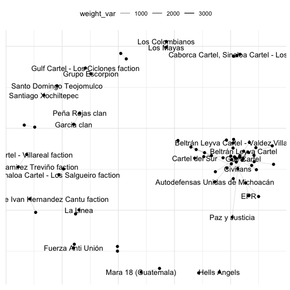

```r
# select 10 random indices from 1 to the length of select_names
select_names <- rownames(mex_network)

set.seed(12345)
random_indices <- sample(length(select_names), 10)

# select 10 random names using the random indices
random_names <- select_names[random_indices]

plot(mex_network,
     add_text = TRUE)
```

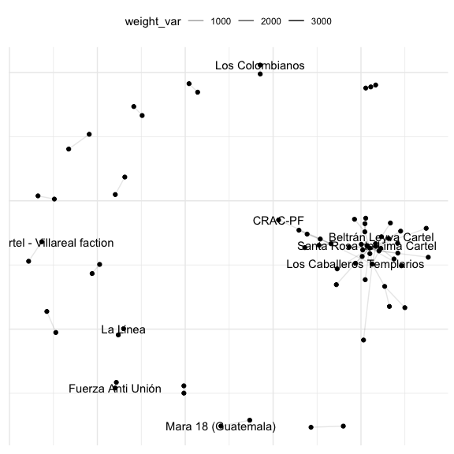

```r
plot(mex_network,
     select_text = random_names,
     select_text_display = random_names)
```

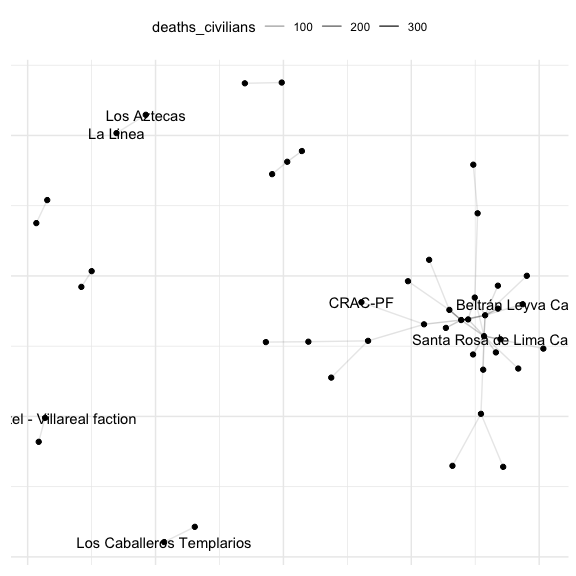

```r
# different edges, highlight same actors, different netify object:
plot(mex_network_civ,
     select_text = random_names,
     select_text_display = random_names)
```

We can also apply functions from `igraph`:

```r
i_opt_memb = function(x){
  ig = prep_for_igraph(x)
  memb = igraph::cluster_optimal(ig)$membership
  return(memb)
  }

# add to summary
sum_mex <- summary_actor(
  mex_network,
  other_stats = list(i_opt_memb=i_opt_memb))
```

## References

- Csárdi G, Nepusz T, Traag V, Horvát S, Zanini F, Noom D, Müller K (2024). igraph: Network Analysis and Visualization in R. doi:10.5281/zenodo.7682609, R package version 2.0.3, https://CRAN.R-project.org/package=igraph.
- Davies, Shawn, Therese Pettersson & Magnus Öberg (2023). Organized violence 1989-2022 and the return of conflicts between states?. Journal of Peace Research 60(4).
- Handcock M, Hunter D, Butts C, Goodreau S, Krivitsky P, Morris M (2018). ergm: Fit, Simulate and Diagnose Exponential-Family Models for Networks. The Statnet Project (http://www.statnet.org). R package version 3.9.4, https://CRAN.R-project.org/package=ergm.
- Hoff, Peter D. “Dyadic data analysis with amen.” arXiv preprint arXiv:1506.08237 (2015).
- Högbladh Stina, 2023, “UCDP GED Codebook version 23.1”, Department of Peace and Conflict Research, Uppsala University
- Miller S (2022). “peacesciencer: An R Package for Quantitative Peace Science Research.” Conflict Management and Peace Science, 39(6), 755–779. doi: 10.1177/07388942221077926.
- Statnet Development Team (Pavel N. Krivitsky, Mark S. Handcock, David R. Hunter, Carter T. Butts, Chad Klumb, Steven M. Goodreau, and Martina Morris) (2003-2023). statnet: Software tools for the Statistical Modeling of Network Data. URL http://statnet.org
- Sundberg, Ralph and Erik Melander (2013) Introducing the UCDP Georeferenced Event Dataset. Journal of Peace Research 50(4).